# Muerte de mujeres ocasionada por su pareja o expareja íntima

2023-06-14

PARTE I

Descripción: La muerte de mujeres ocasionadas por su pareja o ex pareja íntima es un tema muy serio en muchos países de Latinoamérica y el mundo y que ha sido abordado desde la perspectiva normativa, institucional y con políticas públicas específicas. Aunque en muchos lugares se han registrado progresos y las organizaciones luchan por los derechos de las mujeres, la violencia hacia las mujeres aún es altamente preocupante y sigue ocurriendo.

Esta investigación se enfoca en mujeres mayores de 15 años de edad y más que han sido víctimas mortales a manos de sus parejas o ex pareja íntima, con el objetivo de cuantificar su incidencia anualmente. Es importante destacar que mujeres y niñas en todas las regiones del mundo son victimas de este tipo. En cuanto a las variables que serán consideradas en esta investigación, se incluirán:

Año: se seleccionará un rango de años desde 2001 hasta 2021. Países: se seleccionará los países tales Anguila, Antigua y Barbuda, Argentina, Barbados, Belice, Chile, Colombia, Costa Rica, Cuba, Dominica, Ecuador, El Salvador, España, Granada, Guyana, Honduras, Islas Vírgenes Británicas, Jamaica, Montserrat, Nicaragua, Panamá, Paraguay, Perú, Portugal, Puerto Rico, República Dominicana, Saint Kitts y Nevis, San Vicente y las Granadinas, Santa Lucía, Suriname, Trinidad y Tabago, Uruguay, Venezuela (República Bolivariana de Venezuela) Tipo de valor: se seleccionará dos medidas para medir los resultados del planteamiento: tasa por cada 100.000 mujeres y número absoluto. Al utilizar ambas medidas, es posible obtener distintas perspectivas en cuanto a la frecuencia de muertes de mujeres a manos de su pareja o ex pareja. - Tasa por cada 100.000 mujeres, se refiere al cálculo del cociente entre la cantidad total de muertes de mujeres ocasionadas por su pareja o ex pareja íntimapor cada 100.000 mujeres entre la cantidad de poblacion femenina estimados del país evaluado. - Número absoluto, se refiere a la cantidad exacta de casos registrados de muertes de mujeres ocasionada por su pareja o expareja íntima, en lugar de una medida relativa como tasas o proporciones.

Fuentes de datos: Los datos de la investigación fueron recopilados obtenidos de las fuentes mencionadas a continuación:

- Portugal / Annual Report of Internal Safety (RASI)
- Belice / Belize Police Department
- Chile / Chile: - Fiscalía Nacional, Unidad Especializada en Delitos Sexuales y Violencia Intrafamiliar, Informe sobre Muerte de Mujeres, 2012. A partir del año 2010, Información coordinada por el Circuito de Femicidios, instancia intersectorial en la cual participan la Dirección de Protección de la Familia de carabineros (DIPROFAM), el Servicio Nacional de la Mujer (SERNAM), el Servicio Nacional del Menor (SENAME) y el Ministerio del Interior y Seguridad Pública.
- Nicaragua / Comisaría de la Mujer de la Policía Nacional de Nicaragua
- Argentina / Corte Suprema de Justicia de la Nación, Registro Nacional de Femicidios de la Justicia Argentina
- Trinidad y Tabago / Crime and Problem Analysis Branch, Trinidad and Tobago Police Service
- Santa Lucía / Crime Intelligence Unit, Royal St. Lucia Police Force
- Suriname / Dienst Criminele Informatie Verzorging (Service Criminal Information Provision) within the Police Corps Suriname.
- El Salvador / Fiscalía General de la República
- Guyana / Guyana Police Force
- Colombia / Instituto Nacional de Medicina Legal y Ciencias Forenses.
- Honduras / Instituto Universitario en Democracia, Paz y Seguridad (IUDPAS) - Universidad Nacional Autónoma de Honduras (UNAH). Observatorio de Muertes Violentas de Mujeres y Femicidios.
- España / Ministerio de Sanidad, Servicios Sociales e Igualdad.
- Venezuela (República Bolivariana de) / Ministerio Público
- Panamá / Ministério Público, Procuraduría General de la Nación
- San Vicente y las Granadinas / Ministry of National Mobilization, Social Development Departament, Gender Affairs Division.
- Uruguay / Observatorio Violencia y Criminalidad del Ministerio del Interior.
- Costa Rica / Poder Judicial, Observatorio de Violencia de Género contra las Mujeres y Acceso a la Justicia
- Puerto Rico / Policía de Puerto Rico, Informes Estadísticos.
- Paraguay / Policia Nacional y del Ministerio de la Mujer.
- República Dominicana / Procuraduría General de la República.
- Perú / Registro de Feminicidio del Ministerio Público del Perú.
- Jamaica / Research Planning & Legal Services Branch, Jamaica Constabulary Force.
- Barbados / Royal Barbados Police Force.
- Granada / Royal Grenada Police Force
- Antigua y Barbuda / Royal Police Force of Antigua and Barbuda
- Ecuador / Subcomisión Técnica de Validación de la Comisión Especial Interinstitucional de Seguridad y Justicia

Para está investigación, utilizamos la data proporcionada por el sitio web de la Comisión Económica para América Latina y el Caribe (CEPAL) que es una de las cinco comisiones regionales de las Naciones Unidas y su sede está en Santiago de Chile. Cuya investigación trata de gráficar y analizar las Muertes de mujeres ocacionadas por su pareja o expareja íntima sobre 28 países de Latinoamérica y de la Península Ibérica. Además, los datos abarcan un período de 20 años, el cuál inicia en 2001 y finaliza en 2021.

Para comenzar, lo primero que hicimos fue limpiar la data. Para ello realizamos lo siguiente: *Librerías necesarias*

```r
library(readxl)
library(tidyverse)
```

```r
library(tidyr)
library(cowplot)
library(xlsx)
```

*Ver en qué directorio en donde nos encontramos*

```r
getwd()
```

```
## [1] "G:/Usuarios/Iliana Dias/Documentos/GitHub/prueba2-datascience"
```

*Leer el excel de nuestra data*

```r
data <- read_excel("BaseDeDatosOriginal.xlsx")
```

*Ver nuestra la cabecera que esta en la variable data*

```r
head(data)
```

```
## # A tibble: 6 × 8
##   indicator      Tipodevalor País__ESTANDAR Años__ESTANDAR value unit  notes_ids
##   <chr>          <chr>       <chr>          <chr>          <dbl> <chr> <chr>
## 1 Muerte de muj… Tasa (por … Barbados       2013            4.08 Núme… <NA>
## 2 Muerte de muj… Tasa (por … Barbados       2014            1.36 Núme… <NA>
## 3 Muerte de muj… Tasa (por … Chile          2006            0.51 Núme… <NA>
## 4 Muerte de muj… Tasa (por … Chile          2007            0.6  Núme… <NA>
## 5 Muerte de muj… Tasa (por … Chile          2008            0.58 Núme… <NA>
## 6 Muerte de muj… Tasa (por … Chile          2009            0.61 Núme… <NA>
## # ℹ 1 more variable: source_id <dbl>
```

*Cambiar el encabezado de la tabla para una mejor lectura:*

```r
data<- data %>% rename(valor = value) %>% rename(tipodevalor = Tipodevalor) %>% rename(paises = País__ESTANDAR) %>% rename(anio = Años__ESTANDAR)
```

*Ver nuestra data que esta en la variable data*

```r
head(data)
```

```
## # A tibble: 6 × 8
##   indicator             tipodevalor paises anio  valor unit  notes_ids source_id
##   <chr>                 <chr>       <chr>  <chr> <dbl> <chr> <chr>         <dbl>
## 1 Muerte de mujeres oc… Tasa (por … Barba… 2013   4.08 Núme… <NA>           1316
## 2 Muerte de mujeres oc… Tasa (por … Barba… 2014   1.36 Núme… <NA>           1316
## 3 Muerte de mujeres oc… Tasa (por … Chile  2006   0.51 Núme… <NA>            558
## 4 Muerte de mujeres oc… Tasa (por … Chile  2007   0.6  Núme… <NA>            558
## 5 Muerte de mujeres oc… Tasa (por … Chile  2008   0.58 Núme… <NA>            558
## 6 Muerte de mujeres oc… Tasa (por … Chile  2009   0.61 Núme… <NA>            558
```

*Seleccionando las variables de interés y ordenar por anio* **Seleccionamos solo paises, año, valor y tipodevalor porque son las variables de interés para esta investigación**

```r
data <- data %>% select(paises, anio, valor, tipodevalor) %>% arrange(anio)
```

*Ver nuestra data que esta en la variable data*

```r
head(data, 10)
```

```
## # A tibble: 10 × 4
##    paises                       anio   valor tipodevalor
##    <chr>                        <chr>  <dbl> <chr>
##  1 Costa Rica                   2001   0.5   Tasa (por cada 100.000 mujeres)
##  2 San Vicente y las Granadinas 2001  NA     Tasa (por cada 100.000 mujeres)
##  3 Trinidad y Tabago            2001   0.313 Tasa (por cada 100.000 mujeres)
##  4 Costa Rica                   2001  10     Número absoluto
##  5 San Vicente y las Granadinas 2001   1     Número absoluto
##  6 Trinidad y Tabago            2001   2     Número absoluto
##  7 Costa Rica                   2002   0.79  Tasa (por cada 100.000 mujeres)
##  8 San Vicente y las Granadinas 2002  NA     Tasa (por cada 100.000 mujeres)
##  9 Trinidad y Tabago            2002  NA     Tasa (por cada 100.000 mujeres)
## 10 Costa Rica                   2002  16     Número absoluto
```

*Quitar los na de la tabla* **Ya que son valores que no se encontrar al recoger la data**

```r
data<- na.omit(data)
```

*Ver nuestra data que esta en la variable data*

```r
head(data, 10)
```

```
## # A tibble: 10 × 4
##    paises                       anio   valor tipodevalor
##    <chr>                        <chr>  <dbl> <chr>
##  1 Costa Rica                   2001   0.5   Tasa (por cada 100.000 mujeres)
##  2 Trinidad y Tabago            2001   0.313 Tasa (por cada 100.000 mujeres)
##  3 Costa Rica                   2001  10     Número absoluto
##  4 San Vicente y las Granadinas 2001   1     Número absoluto
##  5 Trinidad y Tabago            2001   2     Número absoluto
##  6 Costa Rica                   2002   0.79  Tasa (por cada 100.000 mujeres)
##  7 Costa Rica                   2002  16     Número absoluto
##  8 San Vicente y las Granadinas 2002   2     Número absoluto
##  9 Trinidad y Tabago            2002   7     Número absoluto
## 10 Costa Rica                   2003   0.78  Tasa (por cada 100.000 mujeres)
```

*Ver la variable valores no modificada*

```r
head(data$valor, 10)
```

```
##  [1]  0.5000000  0.3125303 10.0000000  1.0000000  2.0000000  0.7900000
##  [7] 16.0000000  2.0000000  7.0000000  0.7800000
```

*Redondear la variable valor a dos decimales*

```r
data$valor<- round(data$valor, 2)
```

*Ver la variable valores modificada*

```r
head(data$valor, 10)
```

```
##  [1]  0.50  0.31 10.00  1.00  2.00  0.79 16.00  2.00  7.00  0.78
```

PARTE II **Gráficas:** *Comparamos entre los dos tipos de valores que tenemos, es decir, Número Absoluto y tasa por cada 100 mujeres* *Los cuales son dos tipos de forma de ver los datos* *El primer gráfico nos muestra la data en funcion al Tipo “Número Absoluto”*

```r
grafico1 <- data %>% filter(tipodevalor == "Número absoluto") %>%
  ggplot(aes(x = anio, y = valor, fill = tipodevalor)) +
  geom_bar(stat = "identity") +
  xlab("Años (2001-2021)") +
  ylab("Número de muertes de mujer") +
  ggtitle("Muertes de mujeres ocasionadas por su pareja y ex-pareja") +
  scale_y_continuous(limits=c(0, max(data$valor)))
```

*El segundo gráfico nos muestra la data en funcion al Tipo “Tasa(por cada 100.000 mujeres)”*

```r
grafico2 <- data %>% filter(tipodevalor == "Tasa (por cada 100.000 mujeres)") %>%
  ggplot(aes(x = anio, y = valor, fill = tipodevalor))  +
  geom_bar(stat = "identity") +
  xlab("Años (2001-2021)") +
  ylab("Número de muertes de mujer") +
  ggtitle("Muertes de mujeres ocasionadas por su pareja y ex-pareja") +
  scale_y_continuous(limits=c(0, max(data$valor)))
```

*Mostramos ambos gráfico para posteriormente analizar que es lo que podemos notar en él*

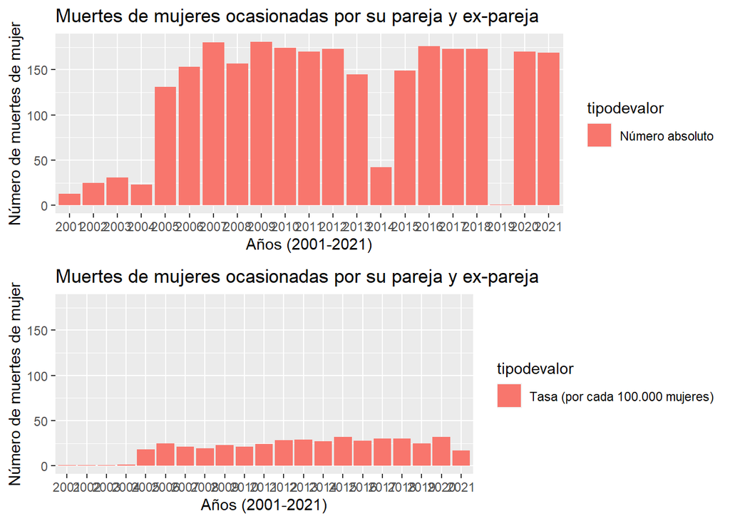

Con respecto al segundo gráfico, es importante señalar que en algunos países con altas cifras de muertes a manos de sus parejas o ex-parejas su tasa de mortalidad por cada 100.000 mujeres son menores debido a que su población femenina es mayor, esto no implica que este tipo de caso sea menos prevalente o menos grave en dichos países.

*Gráficas de línea:* *Se visualizarán los datos en un par de gráficas de línea que muestran la tendencia en las muertes de mujeres ocasionadas por parejas y ex-parejas* Se utilizará una paleta de colores que permita la mejor visualización de las líneas:

```r
colors_vec <- c("#4d4dff", "#00b3b3", "#00cc99", "#b3b300", "#b35900", "#cc99cc", "#ff4d4d", "#808080", "#ff9933", "#6666ff", "#00e6e6", "#b3b3b3", "#ff66ff", "#ffcc99", "#99ff99", "#ff6666", "#b3b300", "#00b3b3", "#ff99cc", "#6666ff", "#ffcc00", "#cc00cc", "#ff4d4d", "#00cc00", "#b35900", "#4d4dff", "#808080", "#FF9933", "#99E6E6", "#FF99CC", "#6666FF", "#FFCC70", "#CC00CC")
names(colors_vec) <- c("Costa Rica", "Trinidad y Tabago", "San Vicente y las Granadinas", "Colombia", "España", "Granada", "Jamaica", "Nicaragua", "Puerto Rico", "República Dominicana", "Santa Lucía", "Suriname", "Dominica", "Saint Kitts y Nevis", "Islas Vírgenes Británicas", "Anguila", "Antigua y Barbuda", "Guyana", "Montserrat", "Chile", "Paraguay", "Uruguay", "Perú", "Honduras", "Barbados", "Belice", "El Salvador", "Argentina", "Venezuela (República Bolivariana de)", "Ecuador", "Portugal", "Cuba", "Panamá")
```

*La primera gráfica muestra la tendencia del número de muertes*

```r
line_absoluto = data %>%
  filter(tipodevalor == 'Número absoluto') %>%
  ggplot(aes(x = anio, y = valor, color = paises)) +
  geom_line(aes(group = paises)) +
  scale_color_manual(values = colors_vec) +
  labs(title = "Tendencia en numero de muertes de mujeres ocasionadas por parejas y  ex-parejas",
       x = "Años (2001-2021)",
       y = "Numero de muertes")
```

*La segunda gráfica muestra la tendencia de la tasa de muertes cada 100.000 mujeres*

```r
line_tasa = data %>%
  filter(tipodevalor == 'Tasa (por cada 100.000 mujeres)') %>%
  ggplot(aes(x = anio, y = valor, color = paises)) +
  geom_line(aes(group = paises)) +
  scale_color_manual(values = colors_vec) +
  labs(title = "Tendencia en la tasa de muertes de mujeres ocasionadas por parejas y  ex-parejas",
       x = "Años (2001-2021)",
       y = "Tasa (por cada 100.000 mujeres)")
```

*Se muestran ambas gráficas para su análisis*

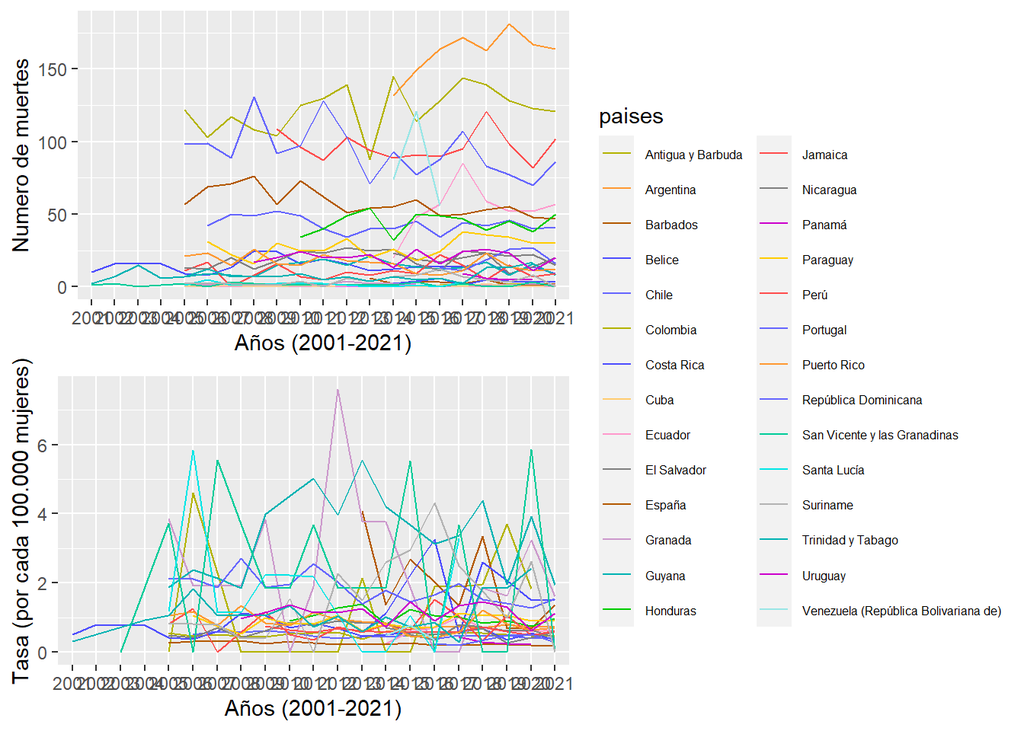

El número de muertes de mujeres por parejas o ex-parejas en muchos paises va aumentando, o mantienen cierta estabilidad, es decir, suben y bajan muy poco. Es interesante destacar que algunos países con altos números de muertes de mujeres por parte de sus parejas o ex-parejas pueden tener tasas relativamente bajas de muertes por cada 100.000 habitantes debido a su población femenina más grande. Sin embargo, esto no significa que la violencia de género sea menos prevalente o menos grave en estos países.

Sin embargo, se puede decir que ya sea en mayor o menor medida la violencia del género femenino se encuentra en todas partes del mundo, y no parecer haber disminuido con el paso de los años ni siquiera con la llegada de las nuevas generaciones que han sido expuestas constantemente a nuevas formas de pensar y a nuevas formas de crianza. De igual forma se podría considerar: ¿Qué pasaría si se obtuvieran más datos concernientes años anteriores?, ¿Cambiaría la percepción obtenida o no?, así como también ¿Será que solo la población femenina resulta ser víctima de homicidio por parte de su pareja o también se podría incluir la población masculina como afectados?